# Efetividade do Senado em 2019

### Votações secretas e abertas

No Senado, as votações podem ser abertas, com os votos explícitos dos senadores; ou secretas, quando há somente a informação de quem estava ou não presente. Essas votações secretas geralmente são feitas para apreciação de mensagens de indicação de autoridades, vetos presidenciais e cassação de parlamentares.

Abaixo, fizemos um levantamento de como estão distribuídos estes tipos de votações nos anos das primeiras legislaturas: 1999, 2003, 2007, 2011, 2015 e 2019.

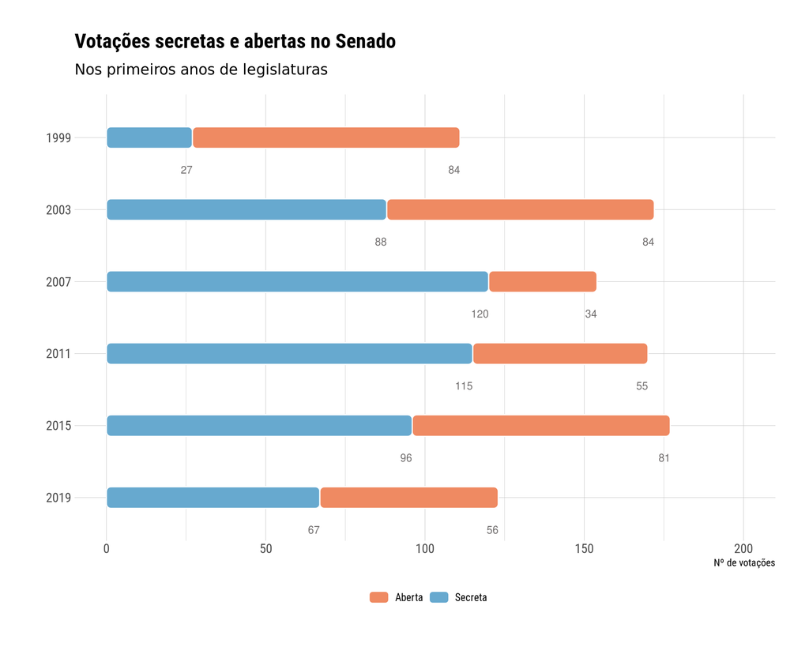

Podemos ver que em 1999 e 2019, primeiros anos de legislatura onde o governo é de direita, o número de votações em si é menor quando comparado aos anos onde o governo era de esquerda.

| Ano | Quantidade de votações |
| --- | --- |
| 1999 | 111 |
| 2003 | 172 |
| 2007 | 154 |
| 2011 | 170 |
| 2015 | 177 |
| 2019 | 123 |

### Proposições votadas ao longo dos anos

A seguir estaremos interessados em analisar o número de proposições votadas. Ou seja, considerando PEC’s, PL’s, MPV’s e demais proposições.

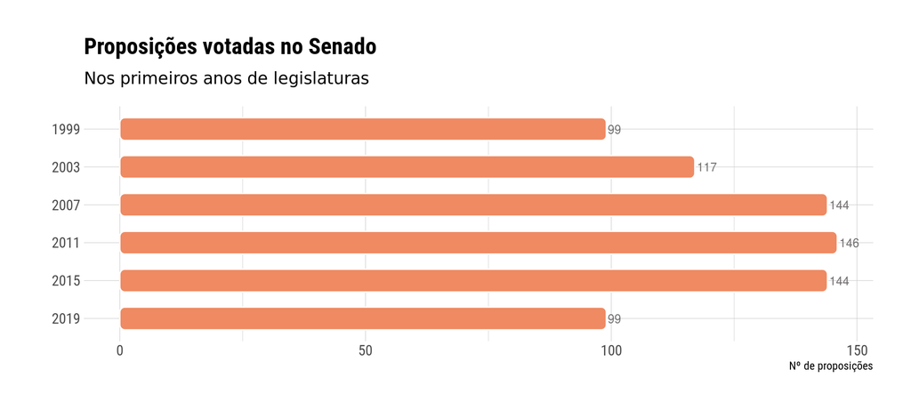

Olhando para o número de proposições votadas percebe-se que 1999 e 2019 são os anos em que o senado votou menos proposições. 2007, 2011 e 2015 são bem próximos no número de proposições votadas com valores perto de 145.

A tabela a seguir é a usada na visualização

| Ano | Quantidade de votações |
| --- | --- |
| 1999 | 99 |
| 2003 | 117 |
| 2007 | 144 |
| 2011 | 146 |
| 2015 | 144 |
| 2019 | 99 |

### Os temas mais votados

As proposições com tema ‘Não especificado’ não foram consideradas. Os temas mais votados no decorrer nos primeiros anos de legislaturas são:

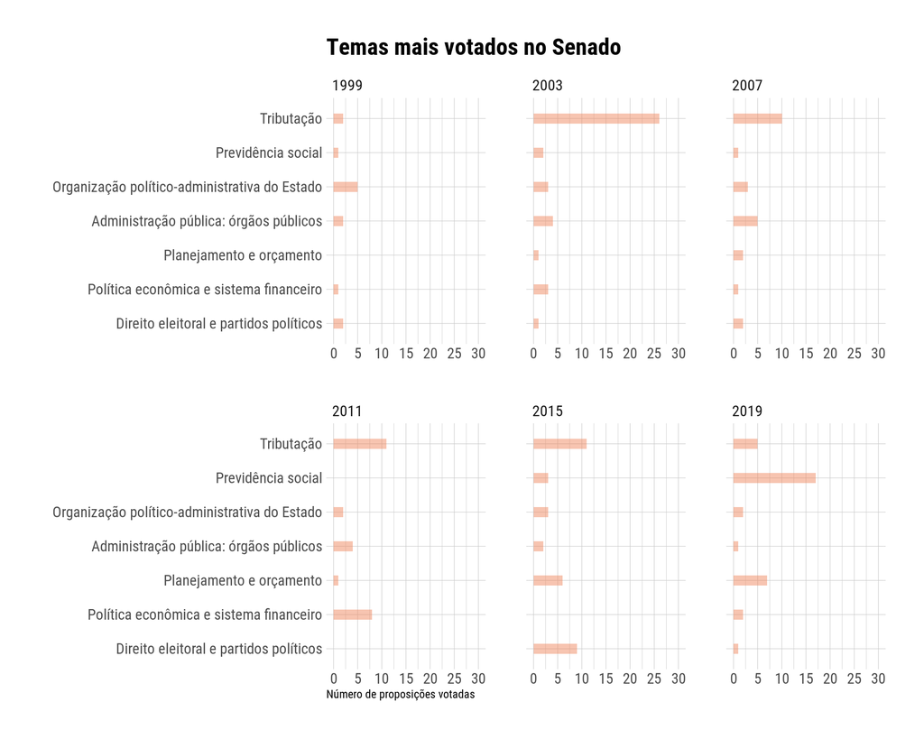

Observando o gráfico acima, percebemos que em 1999, no Governo FHC, os temas das proposições mais votados no Senado foram: Organização político-administrativa do Estado, Administração pública: órgãos públicos e Direito eleitoral e partidos políticos.

Nos governos Lula e Dilma, em 2003, 2007, 2011 e 2015, Tributação foi o tema mais votado; Administração pública: órgãos públicos foi o segundo tema mais votado no governo Lula; Para o governo Dilma, o Política econômica e sistema financeiro ocupa o 2º lugar no primeiro mandato e Direito eleitoral e partidos políticos no segundo.

Em 2019, o tema mais votado foi Previdência social, totalizando 17 votações: 11 foram relacionadas à [PEC 6/2019](https://www25.senado.leg.br/web/atividade/materias/-/materia/137999), 5 sobre a [PEC 133/2019](https://www25.senado.leg.br/web/atividade/materias/-/materia/138555) e uma sobre a [MPV 871/2019](https://www25.senado.leg.br/web/atividade/materias/-/materia/135079).

### Tabela de votações

|  | ano | nome | tema | data_votacao | votacao_secreta | objeto_votacao |
| --- | --- | --- | --- | --- | --- | --- |
| 1 | 2019 | MSF 6/2019 | Nao especificado | 2019-02-26 | 1 | Submete à apreciação do Senado Federal, de conformidade com o art. 52, inciso III, alínea "f", da Constituição Federal, combinado com o art. 6º da Lei nº 6.385, de 7 de dezembro de 1976, com redação d… |
| 2 | 2019 | MSF 2/2019 | Nao especificado | 2019-02-26 | 1 | Submete à apreciação do Senado Federal, nos termos do art. 84, inciso XIV, combinado com o art. 52, inciso III, alínea d, da Constituição Federal, o nome do Senhor ROBERTO DE OLIVEIRA CAMPOS NETO, par… |
| 3 | 2019 | MSF 5/2019 | Nao especificado | 2019-02-26 | 1 | Submete à consideração do Senado Federal, nos termos do o art. 84, inciso XIV, combinado com o art. 52, inciso III, alínea "d", da Constituição, o nome do Senhor BRUNO SERRA FERNANDES, para exercer o … |
| 4 | 2019 | MSF 7/2019 | Nao especificado | 2019-02-26 | 1 | Submete à consideração do Senado Federal, nos termos do o art. 84, inciso XIV, combinado com o art. 52, inciso III, alínea "d", da Constituição, o nome do Senhor JOÃO MANOEL PINHO DE MELLO, para exerc… |
| 5 | 2019 | PEC 25/2017 | Direitos humanos e minorias | 2019-03-12 | 0 | Altera os arts. 7º, 23, 24, 37, 40, 201, 203, 208, 227 e 244 da Constituição Federal para incorporar-lhes a nomenclatura ?pessoa com deficiência?, utilizada pela Convenção Internacional sobre o Direit… |
| 6 | 2019 | PLP 54/2019 (Substitutivo-CD) | Defesa do consumidor | 2019-03-13 | 0 | Altera a Lei Complementar nº 105, de 10 de janeiro de 2001, e a Lei n° 12.414, de 9 de junho de 2011, para dispor sobre os cadastros positivos de crédito e regular a responsabilidade civil dos operado… |
| 7 | 2019 | PEC 25/2017 | Direitos humanos e minorias | 2019-03-19 | 0 | Proposta de Emenda à Constituição nº 25, de 2017 (2º turno) |
| 8 | 2019 | PLC 135/2018 | Indústria, comércio e serviço | 2019-03-19 | 0 | PLC nº 135, de 2018 - Complementar, com as Emendas nºs 1 a 3-CAE (de redação), nos termos do Parecer |
| 9 | 2019 | MSF 3/2019 | Nao especificado | 2019-03-26 | 1 | Submete à apreciação do Senado Federal, de conformidade com o art. 52, inciso IV, da Constituição, e com o art. 39, combinado com o art. 46 da Lei nº 11.440, de 2006, o nome do Senhor OLYNTHO VIEIRA, … |
| 10 | 2019 | PEC 141/2015 | Servidores públicos | 2019-04-02 | 0 | PEC nº 141, de 2015, com as Emendas nºs 1 e 2 - CCJ (redação), no termos do Parecer (1º Turno) |

[output cut: 897 more lines]